# 第五周：第四章 重点解析

School of Social Development

多源数据分析与实践 · Week 5

[interactive chart not shown]

# 第四章 重点解析

主讲人：刘贇喆 副教授 | 华东师范大学 社会发展学院

空间数据导论 · 空间数据读写 · 空间数据处理 · 空间数据可视化 · 空间制图要求与美化

[interactive chart not shown]

目录

**目录** CONTENTS

1.0 空间数据导论

01

SECTION**01 / 05**

## 1.0空间数据导论

Introduction to Spatial Data

1.0 空间数据导论

## 空间数据的两种形态

Vector Features & Raster Cells

空间要素 · 教学示意

12345678

123456

行 × 列**一格，一个值**像元（栅格像素）

1.0 空间数据导论

## 空间点数据

Spatial Point Data

VECTOR LAYER / POINT**点图层**

点击空白处添加点；点击已有点选中。方向键移动准星，按 Enter 放置。这里是 x 从 0 到 100、y 从 0 到 45 的教学坐标，不是真实经纬度。

SF FEATURE TABLE

### 点要素表

| ID | 属性 | 坐标对（x, y） |
| --- | --- | --- |

尚无记录`—`

1.0 空间数据导论

## 空间线数据

Spatial Line Data

VECTOR LAYER / LINE**线图层**

依次放置顶点；至少两点后点“完成线路”，或按 Shift+Enter。这里是 x 从 0 到 100、y 从 0 到 45 的教学坐标，不是真实经纬度。

SF FEATURE TABLE

### 线要素表

| ID | 属性 | 顶点概览 |
| --- | --- | --- |

尚无记录`—`

1.0 空间数据导论

## 空间面数据

Spatial Polygon Data

VECTOR LAYER / POLYGON**面图层**

依次放置至少 3 个不同顶点，再点“闭合并保存”或按 Shift+Enter。方向键移动准星，按 Enter 放置。这里是 x 从 0 到 100、y 从 0 到 45 的教学坐标，不是真实经纬度。

SF FEATURE TABLE

### 面要素表

| ID | 属性 | 闭合顺序 |
| --- | --- | --- |

尚无记录`—`

1.0 空间数据导论

## sf：一个图层，一张要素表

One Layer, One Feature Table

library(sf)

### 三个独立的 sf 图层

[figure not shown]

st_read() → sf

### 一行一个要素，一列一个变量

非空间属性 · ATTRIBUTES**ID · 名称 · 类别 · 数值 · …**

＋

空间／几何属性**geometry***sfc 几何列：位置与形状*

ID名称类别geometry

geometry 预览`点击表格行查看坐标`

1.0 空间数据导论

## 坐标参考系：位置与投影

Coordinate Reference Systems

地球表面与平面地图同一组位置 · 三种地图表达

**地球表面**点击球体查看经纬网

WGS 84 · EPSG:4326

[figure not shown]

**平面地图**经纬度直绘 · 高纬也会变形

CRS · 坐标参考系

### 让坐标对应地球

CRS 定义位置的参照、坐标的表达方式及单位。

点选陆地观察

叠加与量测前

先用 `st_crs()` 核对；需要时用 `st_transform()` 转换。

2.0 空间数据读写

02

SECTION**02 / 05**

## 2.0空间数据读写

Reading and Writing Spatial Data

2.0 空间数据读写

## 空间数据存储方式

How Spatial Data Are Stored

2.0 空间数据读写

## 三种格式读入，GeoJSON 写出

Read with sf · Export as GeoJSON

SOURCE FILES

### 选择一种输入格式

R / sf · 运行前加载 sf + tidyverse

### 读入 sf → 写出新 GeoJSON

nc.shp**→**nc_sf**→****新 .geojson**

```
# 01 · 读入 Shapefile
shp_path <- system.file("shape/nc.shp", package = "sf")
nc_sf <- shp_path %>% st_read(quiet = TRUE)

# 02 · 转为 WGS 84，写出 GeoJSON
out_geojson <- tempfile(fileext = ".geojson")
nc_sf %>%
  st_transform(4326) %>%
  st_write(
    dsn = out_geojson, driver = "GeoJSON",
    layer_options = "RFC7946=YES", quiet = TRUE)

# 03 · 重读并核对
nc_out <- out_geojson %>% st_read(quiet = TRUE)
c(rows = nrow(nc_out), epsg = st_crs(nc_out)$epsg)
```

2.0 空间数据读写

## 从 CSV 坐标表到 sf

From a CSV Table to Spatial Features

伦敦共享单车 · spData / © OpenStreetMap contributors

### `cycle_tbl`

`# A tibble: 12 × 5`

| osm_id <chr> | name <chr> | capacity <dbl> | lon <dbl> | lat <dbl> |
| --- | --- | --- | --- | --- |

TIBBLE COLUMN ROLES

### 识别属性与坐标列

CSV 中 lon / lat 是位置数值列；生成 sf 后才有 geometry。

OBSERVATION 01**Windsor Terrace**

X / lon −0.093388° · Y / lat 51.529125°

R · 已加载 sf + tidyverse

读取 CSV 数据

```
cycle_tbl <- read_csv("cycle_hire_osm_excerpt.csv",
                      col_types = cols(osm_id = col_character()))
```

2.0 空间数据读写

## 把指标接到边界上

Join a Data Table to Spatial Boundaries

### 边界 `boundary_sf`

| geo_id | 名称 | geometry |
| --- | --- | --- |
|  | A 区 | POLYGON |
|  | B 区 | POLYGON |
|  | C 区 | POLYGON |

### 指标 `attr_tbl`

| geo_id | 指标值 |
| --- | --- |
| `"01"` | 8.4 |
| `"03"` | 13.1 |

### 结果 `joined_sf`示意数据

点击上方代码，查看连接结果

3.0 空间数据处理

03

SECTION**03 / 05**

## 3.0空间数据处理

Spatial Data Processing

3.0 空间数据处理

## 从属性处理到空间处理

From Attributes to Spatial Relationships

ONE SF OBJECT

### 同一份 `sf` 数据

一行一个地理要素

非空间属性空间属性

| geo_id | 名称 | 人口 | geometry |
| --- | --- | --- | --- |
| 01 | A 区 | 2.4 万 | POLYGON |
| 02 | B 区 | 1.8 万 | POLYGON |
| 03 | C 区 | 3.1 万 | POLYGON |

沿用第二章

`sf`：带 `geometry` 列的 `data.frame`  
`filter()` 筛选要素 · `mutate()` 新增属性

GEOMETRY IN ACTION

### 让位置参与处理

由 `geometry` 判断要素之间的空间关系

01

**判断空间关系**

点落在哪个区域内？

`st_within()`

02

**空间连接**

按位置匹配，再把区域属性接给点

`st_join()`

03

**几何运算**

按设定距离生成缓冲范围

`st_buffer()`

3.0 空间数据处理

## 空间关系：按位置找到匹配

Spatial predicates · Which features match?

教学示意**点是否位于面 A 内部？**

[figure not shown]

边界上的 Q 与内部的 P，判断结果不同。

判断结果 · `st_within(points_sf, region_sf)`

### 必须进入面内

P → A**匹配**

Q → A**不匹配**

Q 恰在边界上；点归属需先约定边界规则。

3.0 空间数据处理

## 空间连接与叠置

Spatial Join & Overlay

点落入街区，获得街区属性

教学示意 · TWO SF LAYERS

### 站点落在哪个街区？

`points_sf``regions_sf`

**A****居住区**人口 24,000

**B****商业区**人口 18,000

区域外

**P1**位于 A 区 · 居住区 · 人口 24,000连接前核对两图层 CRS

POINT IN POLYGON

### 街区属性写入站点表

点击代码，查看面的属性如何进入点表。

3.0 空间数据处理

## 缓冲区分析：从点生成面

Buffer Analysis · From Point to Polygon

伦敦共享单车站点 · 中心相距约 670 m

### 两座站点，同一缓冲半径

AWaterloo BEmbankment 交叠

[figure not shown]

站点：*spData* 历史 OSM 快照 · © OpenStreetMap contributors | 英国国家格网 EPSG:27700

R / sf

### 两个点，各生成一个面

EPSG:4326 经纬度**→**EPSG:27700 米制投影

```
library(sf)
library(tidyverse)
data("cycle_hire_osm", package = "spData")
stations_m <- cycle_hire_osm %>% st_transform(27700)
centres_m <- stations_m %>%
  filter(name %in% c("Waterloo Bridge, South Bank",
                     "Embankment (Horse Guards)"))
radius_m <- 500
buffers_sf <- centres_m %>% st_buffer(dist = radius_m)
```

缓冲半径

**2 POINTS → 2 POLYGONS**

站间距约 670 m

每站各得一个面，交叠处不会自动合并；500 m 是直线半径，并非步行距离。

3.0 空间数据处理

## st_drop_geometry()：只留下属性

Remove Geometry · Keep the Attributes

输入 · SF

### `points_joined`

| point_id | region_id | area_type | population | geometry |
| --- | --- | --- | --- | --- |
| P1 | A | 居住区 | 24000 | POINT |
| P2 | A | 居住区 | 24000 | POINT |
| P3 | B | 商业区 | 18000 | POINT |
| P4 | B | 商业区 | 18000 | POINT |
| P5 | NA | NA | NA | POINT |

运行函数

### 保留属性

只移除 `geometry`；原 `sf` 不变

输出 · 普通属性表

### `point_tbl`

运行中间的函数，观察哪一列消失。

### 去掉几何后，继续处理属性

先运行 `st_drop_geometry()`，再选择一种属性运算。

4.0 空间数据可视化

04

SECTION**04 / 05**

## 4.0空间数据可视化

Visualizing Spatial Data

4.0 空间数据可视化

## ggplot + sf：用 geom_sf() 绘图

The Same Grammar · A Spatial Geometry Layer

### county_map.R

2025 · 3,108 个县级单元

已整理的县界 sf`class_43_counties`

```
class_43_counties %>%
  ggplot()
```

**ggplot()** 接收 `sf` 数据；此时尚无几何图层。

DRAWN FROM sf

### 美国本土县级边界

**01 / 03**

`class_43_counties %>% ggplot()`

画布已建立，尚未加入绘图图层。

4.0 空间数据可视化

## 同一数据，三种分级断点

Classification Methods · Same Data, Different Breaks

**2025 年美国本土 · 3,108 个县级单元**人口密度（人/km²） → `log10(1 + 密度)` → 五级分色

分级方法各级县数 · 由浅到深四个内部断点 · 人/km²

**Fisher–Jenks****自然断点**

寻找组内差异较小的分组

557 *·* 894 *·* 931 *·* 514 *·* 212

3.915.754.4269.6

**Quantile****分位数**

每级县级单元数尽量接近

622 *·* 621 *·* 622 *·* 621 *·* 622

4.712.325.066.4

**Equal interval****对数等间距**

在对数尺度划分等宽区间

808 *·* 1,626 *·* 548 *·* 117 *·* 9

7.060.5474.23,670.7

4.0 空间数据可视化

## 三种分级方法的地图对比

Three Classification Methods · One County Map

### 美国县级人口密度 · 2025

[figure not shown]

```
classInt::classIntervals(
  ..., style = "fisher"
)
```

密度区间（约）· 人/km²县级单元数

1. 0.03–3.9**557**
2. 3.9–15.7**894**
3. 15.7–54.4**931**
4. 54.4–269.6**514**
5. 269.6–28,370**212**

分级变量：`log10(1 + 人口密度)`

5.0 空间制图要求与美化

05

SECTION**05 / 05**

## 5.0空间制图要求与美化

Cartographic Standards and Design

5.0 空间制图要求与美化

## 中国地图：先过三道检查

Basemap Source · Map Content · Intended Use

01 *BASEMAP*

### 底图有来源

优先在自然资源部标准地图服务系统选择适合图幅的底图。

图名审图号下载日期

仅凭第三方文件名，不能确认地图内容已审核。

02 *EXTENT*

### 内容按图幅核对

中国全图应表达完整范围，并核对图幅和比例尺下应表示的重要岛屿。

大陆海南岛台湾岛南海诸岛

南海附图须清楚。西藏周边等国界关键部位应对照国家标准画法核对；裁切或叠图不得改变、遮挡界线。

03 *USE*

### 按用途核对

课堂练习、直接使用标准图、公开新增专题图，分别记录来源与要求。

课堂练习 **注明来源与限制**直接用标准图 **保留原图与审图号**公开新图 **核对审核要求**

**底图审图号 ≠ 新图审图号**

**三条信息分开写** *底图* 图名 · 审图号 *专题数据* 来源 · 年份 *新图* 用途 · 审核状态

5.0 空间制图要求与美化

## 用 R 制作中国专题地图

A County-Level Choropleth with a South China Sea Inset

Albers 等面积投影

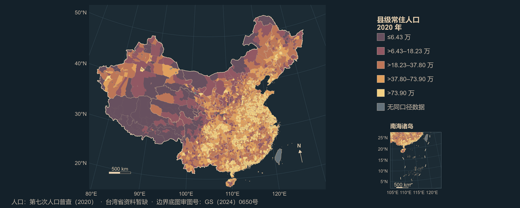

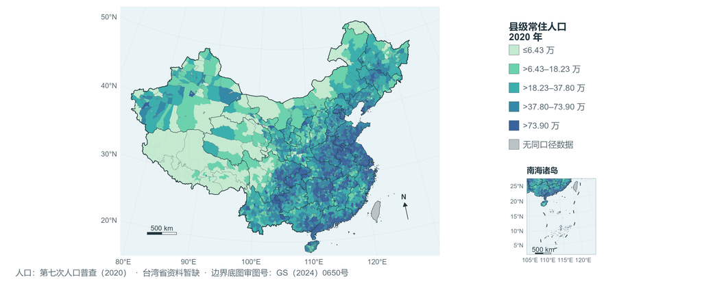

5.0 空间制图要求与美化

## 四种设色方案的地图效果

Categorical · Diverging · Continuous · Classified

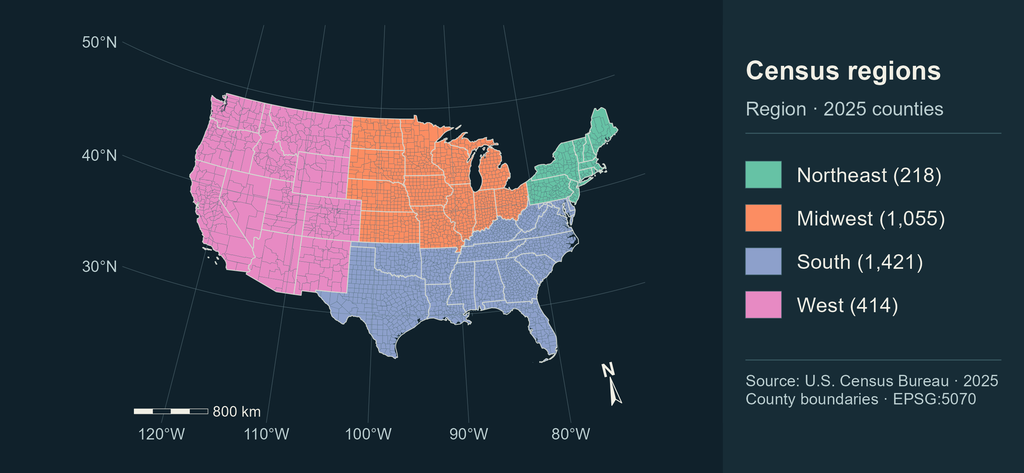

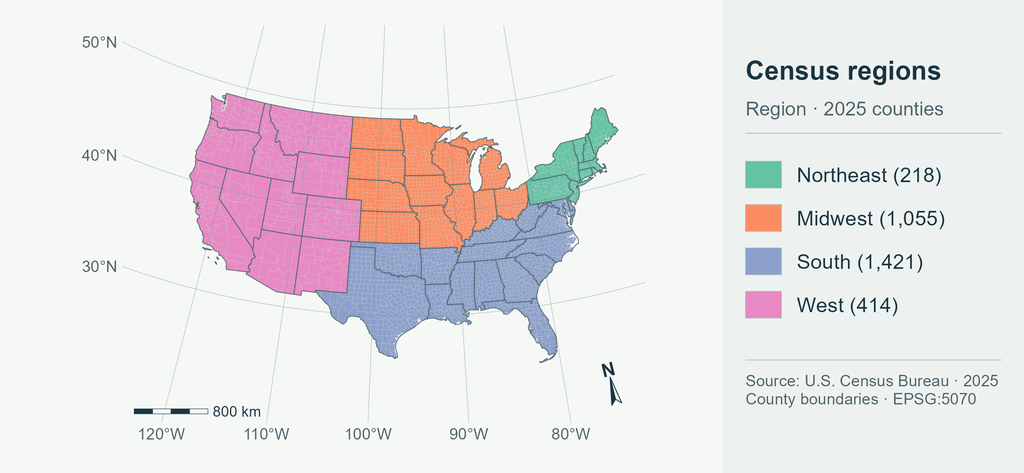

5.0 空间制图要求与美化

## 双变量专题地图

A + B → C · Bivariate Choropleth

A2025 · 人 / km²

### 人口密度

按县级数值分为四档

Q1 低Q4 高

B2020—2025 · %

### 人口变化率

同一批县级单元，另分四档

Q1 低Q4 高

A**×**B*→***4 × 4**

C**美国县级双变量地图**3,108 个县级单元

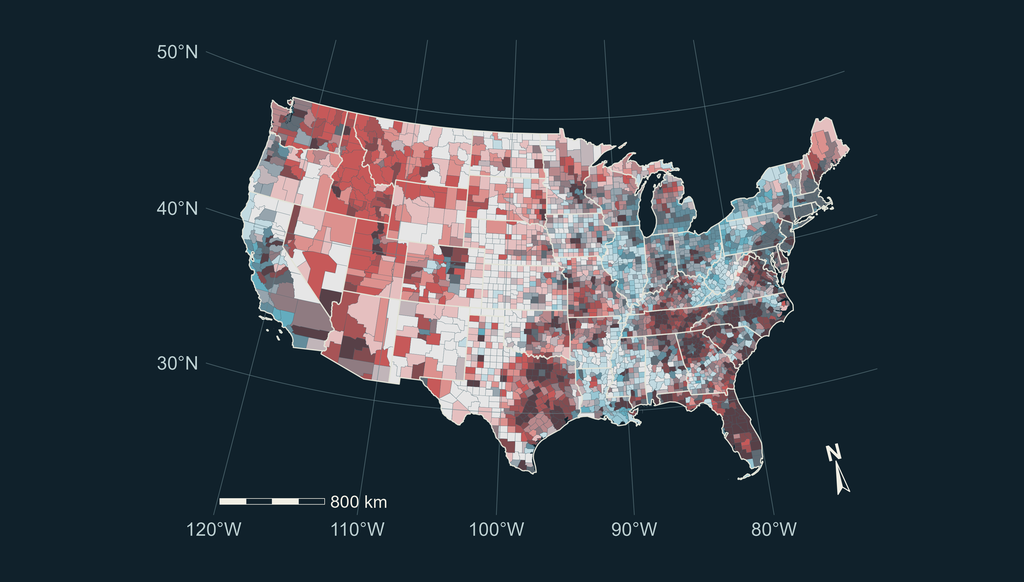

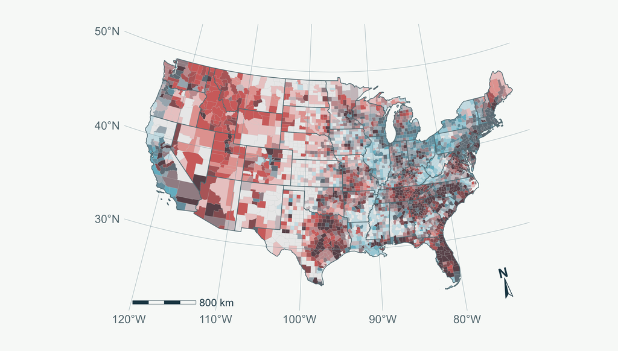

READ THE COLOUR

### 一格颜色 读取两个等级

密度分位 ↑

Q4Q3Q2Q1

Q1Q2Q3Q4

变化率分位 →

多源数据分析与实践 · Week 5

[interactive chart not shown]

# Thanks

第五周：第四章 重点解析

主讲人：刘贇喆 副教授 | 华东师范大学 社会发展学院

01

30

滚轮 / 方向键 / 空格切换

00:00:00